# Establishing the distribution of three agar-producing seaweed species in relation to existing Marine Protected Areas (MPAs) in South Africa

Lilith Diener

2025-03-01

To assess whether new Marine Protected Areas (MPAs) should be established or existing ones expanded for the conservation of South Africa’s main agar-producing seaweed species, I outline my step-by-step workflow below.

Firstly, I install and load all necessary packages.

```r
# Install packages
# install.packages("ggmap")
# install.packages("ggmap", dependencies = TRUE)
# install.packages("ggspatial")
# install.packages("osmdata")
# install.packages("wesanderson")

# Load packages
library(sf)
library(tidyverse)
```

```r
library(ggplot2)
library(rinat)
library(rosm)
library(ggspatial)
library(ggmap)
library(osmdata)
library(leaflet)
library(htmltools)
library(mapview)
library(leafpop)
library(wesanderson)
library(dplyr)
```

Now I can read in my first data set - the South African Marine Protected Areas. I am checking the data set’s CRS and looking at the first few rows of the attribute table.

```r
# Read in the Marine Protected Areas data set
mpa <- st_read("C:\\Users\\Win10\\Documents\\GIT\\Gracilaria\\Gracilaria\\data\\SAMPAZ_OR_2024_Q3.shp")
# Check the CRS
st_crs(mpa)
```

```
## Coordinate Reference System:
##   User input: GCS_LatLong_WGS84
##   wkt:
## GEOGCRS["GCS_LatLong_WGS84",
##     DATUM["World Geodetic System 1984",
##         ELLIPSOID["WGS 84",6378137,298.257223563,
##             LENGTHUNIT["metre",1]],
##         ID["EPSG",6326]],
##     PRIMEM["0.0",0,
##         ANGLEUNIT["Degrees",0.0174532925199433]],
##     CS[ellipsoidal,2],
##         AXIS["longitude",east,
##             ORDER[1],
##             ANGLEUNIT["Degrees",0.0174532925199433]],
##         AXIS["latitude",north,
##             ORDER[2],
##             ANGLEUNIT["Degrees",0.0174532925199433]]]
```

```r
class(mpa)
```

```
## [1] "sf"         "data.frame"
```

```r
head (mpa)
```

```
## Simple feature collection with 6 features and 11 fields
## Geometry type: MULTIPOLYGON
## Dimension:     XY
## Bounding box:  xmin: 17.41669 ymin: -36.03341 xmax: 28.96201 ymax: -32.18798
## Geodetic CRS:  GCS_LatLong_WGS84
##      WDPAID                                           CUR_NME
## 1    300546                 Dwesa-Cwebe Marine Protected Area
## 2    300546                 Dwesa-Cwebe Marine Protected Area
## 3    300546                 Dwesa-Cwebe Marine Protected Area
## 4 555571018        Agulhas Bank Complex Marine Protected Area
## 5 555571029 Addo Elephant National Park Marine Protected Area
## 6 555571023                 Cape Canyon Marine Protected Area
##                             CUR_ZON_NM CUR_ZON_TY CUR_ZON_CD WMCM_TYPE MAJ_TYPE
## 1             Northern Controlled Zone Controlled      DCNCZ  National       PA
## 2              Central Controlled Zone Controlled      DCCCZ  National       PA
```

[output cut: 18 more lines]

```r
# Write data with sf
 st_write(mpa, "C:\\Users\\Win10\\Documents\\GIT\\Gracilaria\\Gracilaria\\data\\SAMPAZ_OR_2024_Q3_duplicate.shp", append = FALSE)
```

```
## Deleting layer `SAMPAZ_OR_2024_Q3_duplicate' using driver `ESRI Shapefile'
## Writing layer `SAMPAZ_OR_2024_Q3_duplicate' to data source
##   `C:\Users\Win10\Documents\GIT\Gracilaria\Gracilaria\data\SAMPAZ_OR_2024_Q3_duplicate.shp' using driver `ESRI Shapefile'
## Writing 161 features with 11 fields and geometry type Multi Polygon.
```

```r
file.exists("C:\\Users\\Win10\\Documents\\GIT\\Gracilaria\\Gracilaria\\data\\SAMPAZ_OR_2024_Q3_duplicate.shp")
```

```
## [1] TRUE
```

Here, I generate some plots to get an overview of the MPA data, I then reduce it to show only the relevant column (MPA names) and create an additional plot using tidyverse, which also creates a legend. In this last plot the map is squashed, but I will fix this in the next step.

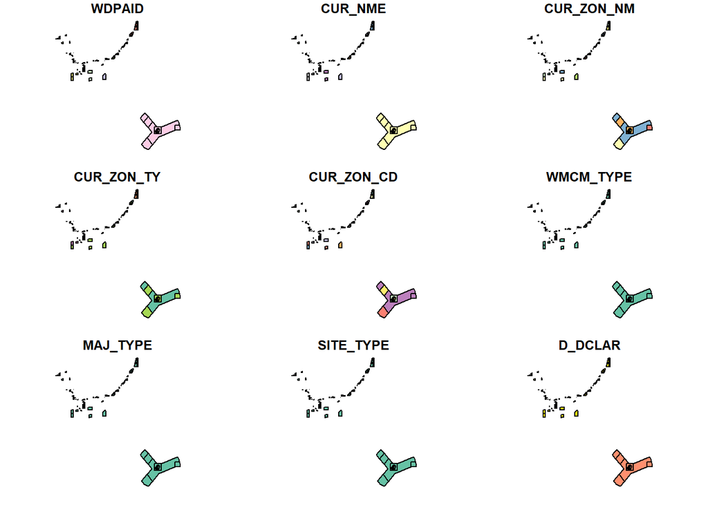

```r
# Plot all (all columns, all of SA)
plot(mpa)
```

Figure 1: Plots of the properties of each attribute in the MPA attribute table.

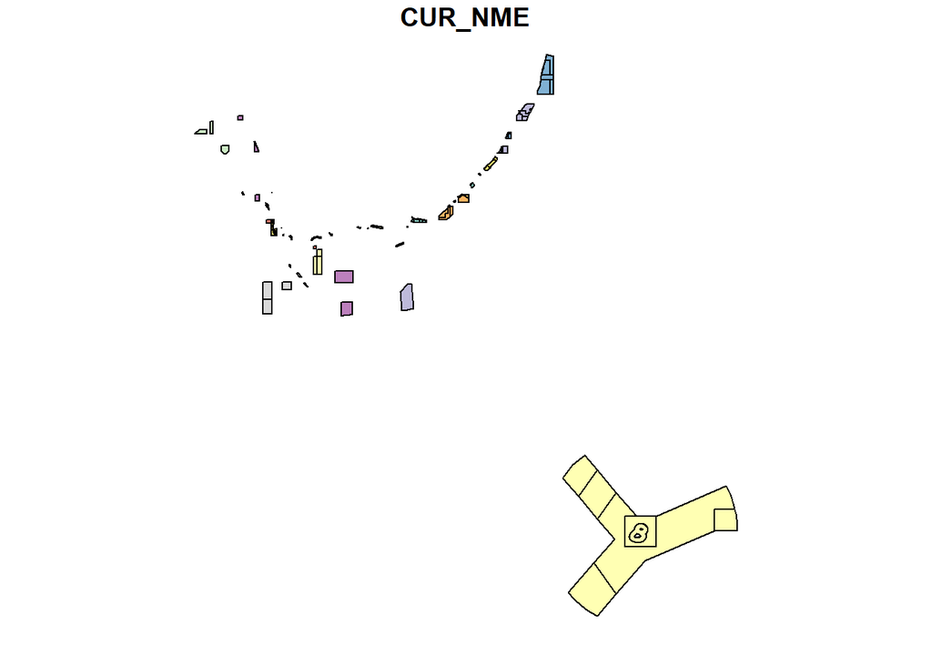

```r
# Plot only column 2 from attribute table, all of SA
 plot(mpa[2])
```

Figure 2: Map of South African Marine Protected Areas by name.

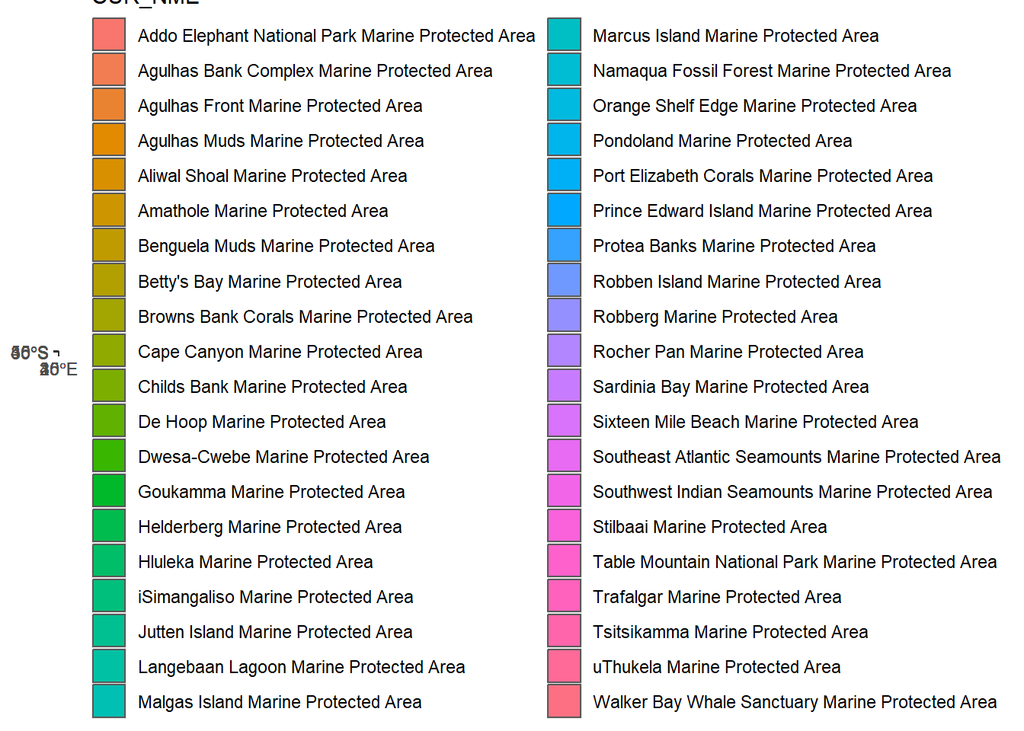

```r
# Plot using tidyverse
ggplot() + geom_sf(data=mpa, aes(fill = `CUR_NME`))
```

Figure 3: Map of South African Marine Protected Areas with legend.

To avoid squashing the map, I crop it to the section I want to show. I set the bounding box to show the Cape Peninsula, and extend west and north to include Robben Island, and east and south to include more of False Bay.

```r
 # Define bounding box size
xmin <- 18.0   # Extend west to include Robben Island
xmax <- 19.2   # Extend east to include parts of False Bay
ymin <- -34.6  # Extend south to cover more of False Bay
ymax <- -33.7  # Extend north to include Robben Island
```

I create a bounding box with the same CRS as my MPA data, crop it to the Cape Peninsula region and surrounding areas, and plot this.

```r
# Create a bounding box with the same CRS as the MPA data
cape_bbox <- st_bbox(c(xmin = xmin, xmax = xmax, ymin = ymin, ymax = ymax), crs = st_crs(mpa))

# Crop the MPA data to the chosen region
mpa_cape <- st_crop(mpa, cape_bbox)
```

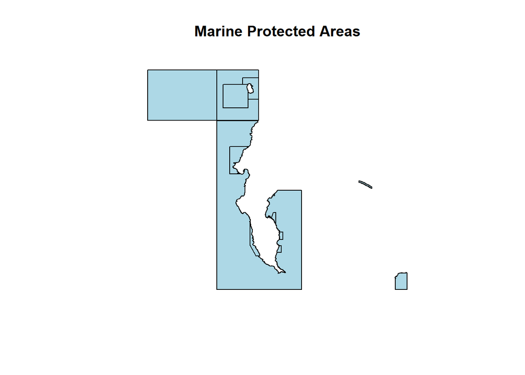

```r
# Plot only cropped section of Cape Peninsula
plot(st_geometry(mpa_cape), col = 'lightblue', main = "Marine Protected Areas")
```

Figure 4: Map of South African MPAs in the Cape Peninsula region, Robben Island and False Bay.

I create a plot using ggplot2 showing the four MPAs included in my cropped section in different colours. For this to work, I first convert my MPA data to a data frame.

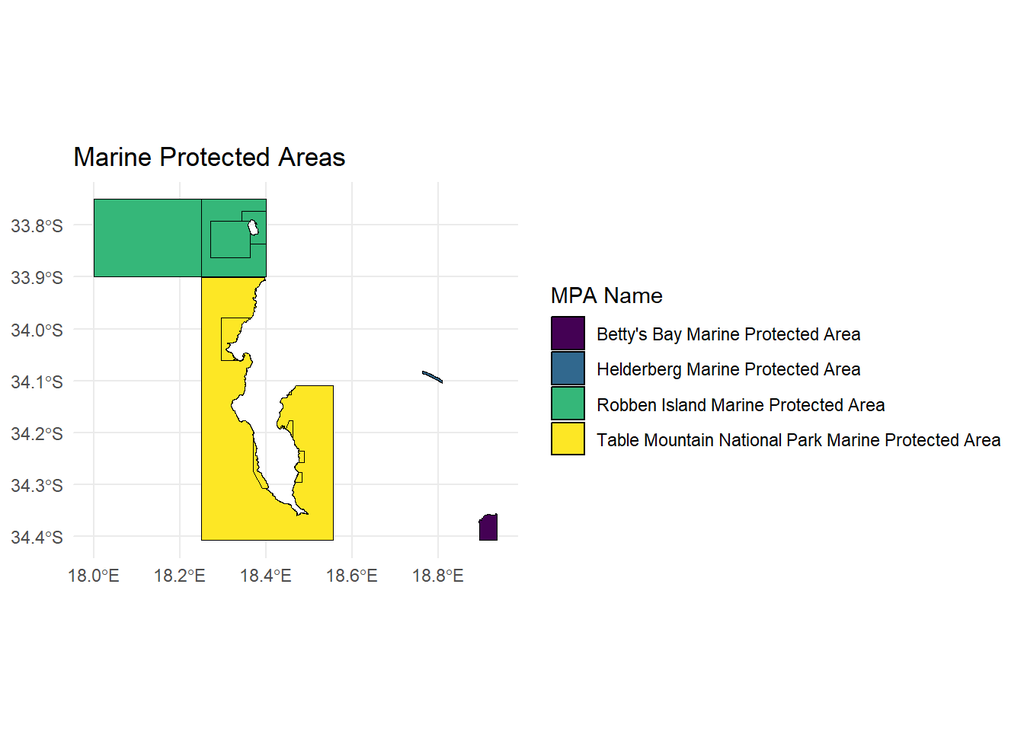

```r
# Convert MPA data to a data frame for ggplot2
mpa_cape$MPA_NAME <- as.factor(mpa_cape$CUR_NME)  # Convert MPAs to factor values

# Plot colour-coded MPAs
ggplot() +
  geom_sf(data = mpa_cape, aes(fill = CUR_NME), color = "black") +
  scale_fill_viridis_d(name = "MPA Name") +
  ggtitle("Marine Protected Areas") +
  theme_minimal() +
  theme(legend.position = "right")
```

Figure 5: Map of South African MPAs in the Cape Peninsula region, Robben Island and False Bay, MPAs are highlighted in different colours.

There are some adjacent polygons that belong to the same MPA. Below I edit the plot to not show any unwanted boundaries.

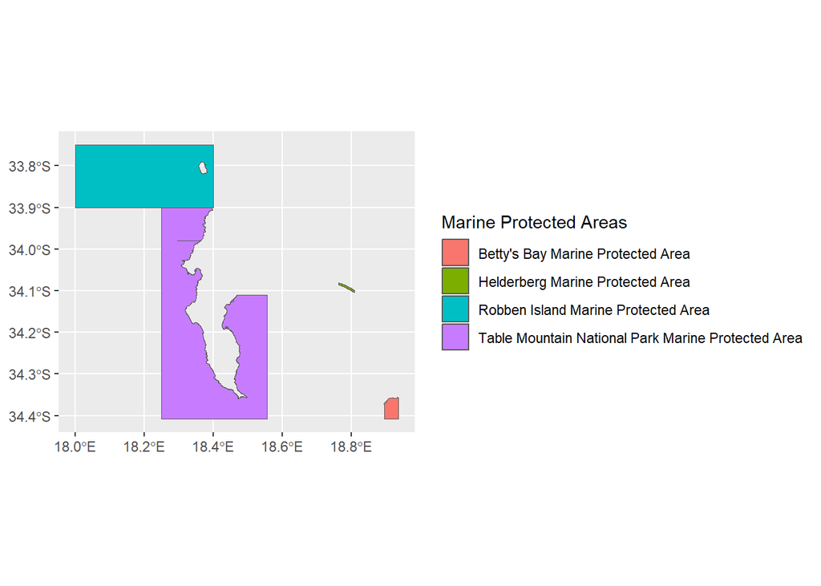

```r
# Remove boundaries within MPAs
mpa_cape %>% group_by(CUR_NME) %>%
  summarize() %>%
  ggplot() + geom_sf(aes(fill = CUR_NME)) +
  scale_fill_discrete(name = "Marine Protected Areas")
```

Figure 6: Map of South African MPAs in the Cape Peninsula region, Robben Island and False Bay, unwanted boundaries are removed.

Now it is time to add my species occurrence data from iNaturalist. I am using three species: the kelps *Ecklonia maxima* and *Laminaria pallida*, and the red alga *Gelidium pristoides*. I do this using the rinat() package.

```r
# Call species occurrence data from iNaturalist

# Ecklonia maxima
em <- get_inat_obs(taxon_name = "Ecklonia maxima",
                   bounds = c(-34.6, 18.0, -33.7, 19.2),
                   maxresults = 1000)

# View the first few rows of data
head(em)
```

```
##   scientific_name                  datetime description
## 1 Ecklonia maxima 2025-02-26 11:13:32 +0200
## 2 Ecklonia maxima 2025-02-20 14:25:41 +0200
## 3 Ecklonia maxima 2025-01-20 11:58:00 +0200
## 4 Ecklonia maxima 2025-01-20 11:56:00 +0200
## 5 Ecklonia maxima 2024-12-05 18:38:26 +0200
## 6 Ecklonia maxima 2024-06-28 16:35:00 +0200
##                                            place_guess  latitude longitude
## 1    Table Mountain National Park, ZA-WC-CT, ZA-WC, ZA -34.26490  18.46682
## 2                                         South Africa -34.09009  18.55851
## 3     Dalebrook Tidal Pool, Dalebrook Rd, South Africa -34.12395  18.45297
## 4     Dalebrook Tidal Pool, Dalebrook Rd, South Africa -34.12395  18.45297
## 5 Cape Town City Centre, Cape Town, 8000, South Africa -33.92080  18.42314
## 6                         City of Cape Town, ZA-WC, ZA -34.05862  18.32639
##   tag_list common_name                                                url
```

[output cut: 62 more lines]

```r
# Gelidium pristoides
gpr <- get_inat_obs(taxon_name = "Gelidium pristoides",
                   bounds = c(-34.6, 18.0, -33.7, 19.2),
                   maxresults = 1000)

#View the first few rows of data
head(gpr)
```

```
##       scientific_name                  datetime description
## 1 Gelidium pristoides 2024-09-23 13:22:26 +0200
## 2 Gelidium pristoides 2023-03-26 10:10:00 +0200
## 3 Gelidium pristoides 2023-03-26 10:06:00 +0200
## 4 Gelidium pristoides 2023-03-26 09:52:00 +0200
## 5 Gelidium pristoides 2022-05-02 10:36:30 +0200        Alge
## 6 Gelidium pristoides 2022-05-01 11:09:53 +0200
##                                                                         place_guess
## 1                                                      South Atlantic Ocean, WC, ZA
## 2 Danger Beach Rock Pools, St James, Main Rd, Cape Town, Western Cape, South Africa
## 3 Danger Beach Rock Pools, St James, Main Rd, Cape Town, Western Cape, South Africa
## 4 Danger Beach Rock Pools, St James, Main Rd, Cape Town, Western Cape, South Africa
## 5                                                      City of Cape Town, ZA-WC, ZA
## 6                                       M4, Cape Peninsula, Cape Town, South Africa
##    latitude longitude tag_list       common_name
```

[output cut: 69 more lines]

```r
# Laminaria pallida
lp <- get_inat_obs(taxon_name = "Laminaria pallida",
                   bounds = c(-34.6, 18.0, -33.7, 19.2),
                   maxresults = 1000)

# View the first few rows of data
head(lp)
```

```
##     scientific_name                  datetime description
## 1 Laminaria pallida 2023-11-27 09:39:05 +0200
## 2 Laminaria pallida 2025-02-01 17:04:56 +0200
## 3 Laminaria pallida 2025-01-20 14:17:00 +0200
## 4 Laminaria pallida 2024-11-29 16:37:09 +0200
## 5 Laminaria pallida 2024-10-19 11:00:00 +0200
## 6 Laminaria pallida 2018-12-06 23:16:00 +0200
##                                          place_guess  latitude longitude
## 1                       South Atlantic Ocean, WC, ZA -34.17244  18.33568
## 2                      Witsand Bay, Western Cape, ZA -34.17807  18.34478
## 3      City of Cape Town, Western Cape, South Africa -34.19396  18.44666
## 4      Bakoven, Кейптаун, Провинция Вестерн-Кейп, ZA -33.95345  18.37505
## 5 Cape Winelands District Municipality, South Africa -34.20073  18.45662
## 6                       City of Cape Town, ZA-WC, ZA -34.20809  18.46322
##   tag_list    common_name                                                url
```

[output cut: 62 more lines]

I now merge the 3 data sets into a single data frame and filter the data so that it only shows research grade observations and records from the wild (not found in aquaculture farming systems).

```r
# Merge the 3 data sets into a single data frame
algae_data <- rbind(gpr, em, lp)

# Check structure
str(algae_data)
```

```
## 'data.frame':    1157 obs. of  37 variables:
##  $ scientific_name                 : chr  "Gelidium pristoides" "Gelidium pristoides" "Gelidium pristoides" "Gelidium pristoides" ...
##  $ datetime                        : chr  "2024-09-23 13:22:26 +0200" "2023-03-26 10:10:00 +0200" "2023-03-26 10:06:00 +0200" "2023-03-26 09:52:00 +0200" ...
##  $ description                     : chr  "" "" "" "" ...
##  $ place_guess                     : chr  "South Atlantic Ocean, WC, ZA" "Danger Beach Rock Pools, St James, Main Rd, Cape Town, Western Cape, South Africa" "Danger Beach Rock Pools, St James, Main Rd, Cape Town, Western Cape, South Africa" "Danger Beach Rock Pools, St James, Main Rd, Cape Town, …
##  $ latitude                        : num  -34.2 -34.1 -34.1 -34.1 -34.1 ...
##  $ longitude                       : num  18.5 18.5 18.5 18.5 18.8 ...
##  $ tag_list                        : chr  "" "" "" "" ...
##  $ common_name                     : chr  "Sawedge Jellyweed" "Sawedge Jellyweed" "Sawedge Jellyweed" "Sawedge Jellyweed" ...
##  $ url                             : chr  "https://www.inaturalist.org/observations/243650677" "https://www.inaturalist.org/observations/153036263" "https://www.inaturalist.org/observations/152640471" "https://www.inaturalist.org/observations/152640446" ...
##  $ image_url                       : chr  "https://inaturalist-open-data.s3.amazonaws.com/photos/434493698/medium.jpeg" "https://inaturalist-open-data.s3.amazonaws.com/photos/264259453/medium.jpeg" "https://inaturalist-open-data.s3.amazonaws.com/photos/263510552/medium.jpeg" "https://inaturalist-…
##  $ user_login                      : chr  "natureconnectsa" "jeremygilmore" "jeremygilmore" "jeremygilmore" ...
##  $ id                              : int  243650677 153036263 152640471 152640446 115691155 114795525 114668842 114666587 114605814 114605142 ...
##  $ species_guess                   : chr  "Sawedge Jellyweed" "Gelidium pristoides" "Gelidium pristoides" "Gelidium pristoides" ...
##  $ iconic_taxon_name               : chr  "Plantae" "Plantae" "Plantae" "Plantae" ...
```

[output cut: 23 more lines]

```r
# Filter returned observations by a range of column attribute criteria
algae_data <- algae_data %>% filter(positional_accuracy<46 &
                latitude<0 &
                !is.na(latitude) &
                captive_cultivated == "false" &
                quality_grade == "research")

class(algae_data) # check class
```

```
## [1] "data.frame"
```

I convert the data frame into a spatial object. I define the CRS to be Geographic WGS84 using the EPSG code.

```r
# Make the data frame a spatial object of class = "sf"
algae_data <- st_as_sf(algae_data, coords = c("longitude", "latitude"), crs = 4326)

class(algae_data) # confirm new classes
```

```
## [1] "sf"         "data.frame"
```

```r
# Check for new "geometry" column
names(algae_data)
```

```
##  [1] "scientific_name"                  "datetime"
##  [3] "description"                      "place_guess"
##  [5] "tag_list"                         "common_name"
##  [7] "url"                              "image_url"
##  [9] "user_login"                       "id"
## [11] "species_guess"                    "iconic_taxon_name"
## [13] "taxon_id"                         "num_identification_agreements"
## [15] "num_identification_disagreements" "observed_on_string"
## [17] "observed_on"                      "time_observed_at"
## [19] "time_zone"                        "positional_accuracy"
## [21] "public_positional_accuracy"       "geoprivacy"
## [23] "taxon_geoprivacy"                 "coordinates_obscured"
## [25] "positioning_method"               "positioning_device"
## [27] "user_id"                          "user_name"
## [29] "created_at"                       "updated_at"
## [31] "quality_grade"                    "license"
## [33] "sound_url"                        "oauth_application_id"
## [35] "captive_cultivated"               "geometry"
```

I create the first plot that includes the 3 species occurrences within the MPAs.

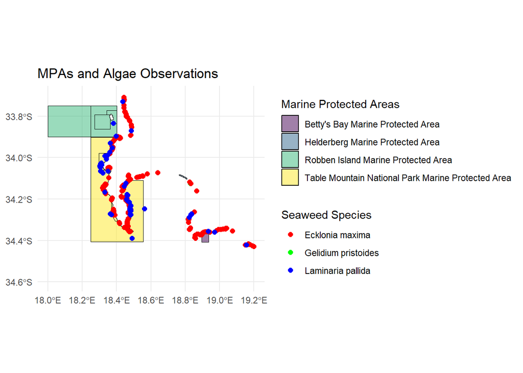

```r
# Plot 3 seaweed species with MPAs and legend
ggplot() +
  geom_sf(data = mpa_cape, aes(fill = CUR_NME), color = "black", alpha = 0.5) +
  geom_sf(data = algae_data, aes(color = scientific_name), size = 2) +
  scale_fill_viridis_d(name = "Marine Protected Areas") +
  scale_color_manual(name = "Seaweed Species", values = c("red", "green", "blue", "yellow")) +
  coord_sf(xlim = c(18.0, 19.2), ylim = c(-34.6, -33.7)) +
  ggtitle("MPAs and Algae Observations") +
  theme_minimal() +
  theme(legend.position = "right")
```

Figure 7: Observations of three seaweed species within existing MPAs. Species and MPAs are highlighted in different colours.

I create an interactive map with a default OSM base map that allows me to zoom into specific areas and has popup labels with URL links to each observation on iNaturalist.

```r
# Make an interactive map
leaflet() %>%
  addTiles(group = "Default") %>%
  addCircleMarkers(data = algae_data,
                   group = "Seaweeds",
                   radius = 3,
                   color = "green")
```

[interactive chart not shown]

Figure 8: Interactive map showing seaweed observations within the broader Cape region.

I am adding popup labels that show the Feature ID, the species’ scientific name, and whether they are cultivated.

```r
# Add popup labels
mapview(algae_data,
        popup =
          popupTable(algae_data,
            zcol = c("scientific_name", "captive_cultivated", "url")))
```

[interactive chart not shown]

Figure 9: Interactive map showing seaweed observations within the broader Cape region, with popup labels.

Now I am adding URL links to each observation on iNaturalist.

```r
# Make URLs links
l_algae_data <- algae_data %>%
  mutate(click_url = paste("<b><a href='", url, "'>Link to iNat observation</a></b>"))

mapview(algae_data,
        popup =
          popupTable(l_algae_data,
            zcol = c("scientific_name", "captive_cultivated", "click_url")))
```

[interactive chart not shown]

Figure 10: Interactive map showing seaweed observations within the broader Cape region, with popup labels and URL links to iNaturalist observations.

I want to now intersect the MPA and species data sets. The CRS of the two do not match, so I first transform one data set to match the other and then intersect.

```r
# Transform one data set to match the other
algae_data <- st_transform(algae_data, st_crs(mpa_cape))

# Confirm CRS of both data sets
st_crs(algae_data)
```

```
## Coordinate Reference System:
##   User input: GCS_LatLong_WGS84
##   wkt:
## GEOGCRS["GCS_LatLong_WGS84",
##     DATUM["World Geodetic System 1984",
##         ELLIPSOID["WGS 84",6378137,298.257223563,
##             LENGTHUNIT["metre",1]],
##         ID["EPSG",6326]],
##     PRIMEM["0.0",0,
##         ANGLEUNIT["Degrees",0.0174532925199433]],
##     CS[ellipsoidal,2],
##         AXIS["longitude",east,
##             ORDER[1],
##             ANGLEUNIT["Degrees",0.0174532925199433]],
##         AXIS["latitude",north,
##             ORDER[2],
##             ANGLEUNIT["Degrees",0.0174532925199433]]]
```

```r
st_crs(mpa_cape)
```

```
## Coordinate Reference System:
##   User input: GCS_LatLong_WGS84
##   wkt:
## GEOGCRS["GCS_LatLong_WGS84",
##     DATUM["World Geodetic System 1984",
##         ELLIPSOID["WGS 84",6378137,298.257223563,
##             LENGTHUNIT["metre",1]],
##         ID["EPSG",6326]],
##     PRIMEM["0.0",0,
##         ANGLEUNIT["Degrees",0.0174532925199433]],
##     CS[ellipsoidal,2],
##         AXIS["longitude",east,
##             ORDER[1],
##             ANGLEUNIT["Degrees",0.0174532925199433]],
##         AXIS["latitude",north,
##             ORDER[2],
##             ANGLEUNIT["Degrees",0.0174532925199433]]]
```

```r
# Intersect species occurrences and MPAs
mpa_em_lp_gpr <- st_intersection(algae_data, mpa_cape)
# Check dimensions before and after intersection
dim(algae_data) # before
```

```
## [1] 565  36
```

```r
algae_data <- st_intersection(algae_data, mpa_cape) # intersect
dim(algae_data) # after
```

```
## [1] 176  48
```

Now I create a plot of the intersected data with an OSM base map. The species records from different MPAs are indicated in different colours.

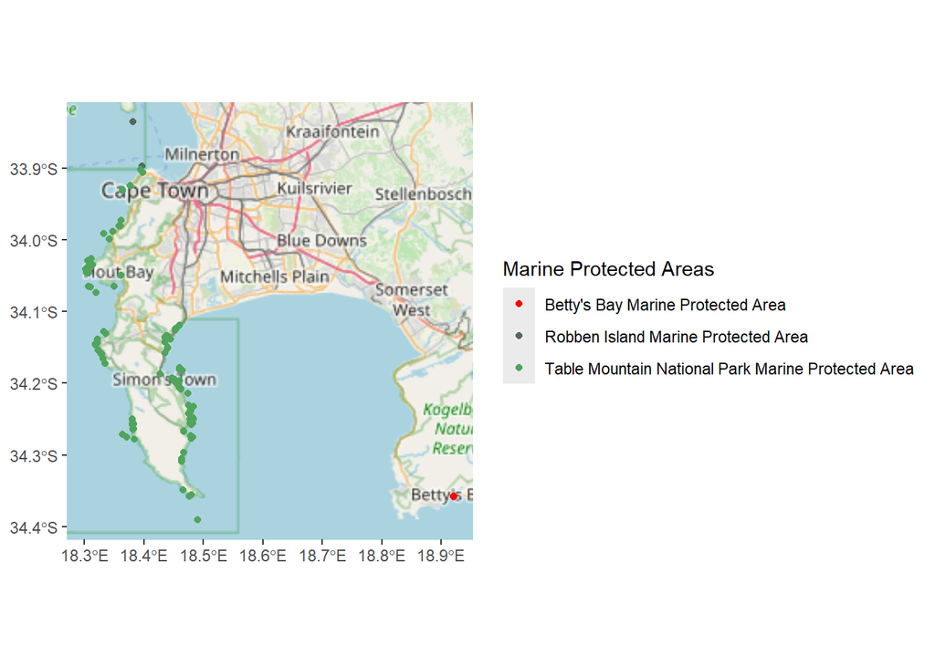

```r
# Plot intersected data set and colour points
pal <- wes_palette("Darjeeling1", 7, type = "continuous")

ggplot() +
  annotation_map_tile(type = "osm", progress = "none") +
  geom_sf(data = algae_data, aes(col = CUR_NME)) +
  scale_colour_manual(name = "Marine Protected Areas", values = pal)
```

Figure 11: Map of seaweed species occurrences within the MPAs and with an Open street map base map. Species records from different MPAs are indicated in different colours.

It looks like almost all species records are in the Table Mountain National Park Marine Protected Area. Let us confirm this.

```r
algae_data %>% group_by(CUR_NME) %>% summarise(n())
```

```
## Simple feature collection with 3 features and 2 fields
## Geometry type: MULTIPOINT
## Dimension:     XY
## Bounding box:  xmin: 18.3015 ymin: -34.3898 xmax: 18.92145 ymax: -33.835
## Geodetic CRS:  GCS_LatLong_WGS84
## # A tibble: 3 × 3
##   CUR_NME                                        `n()`                  geometry
##   <chr>                                          <int>          <MULTIPOINT [°]>
## 1 Betty's Bay Marine Protected Area                  2 ((18.92128 -34.35774), (…
## 2 Robben Island Marine Protected Area                2 ((18.3817 -33.835), (18.…
## 3 Table Mountain National Park Marine Protected…   172 ((18.33408 -34.17229), (…
```

When we have a look at the numbers in column n(), this proves to be correct. It is difficult to see where the few records within the Betty’s Bay (BB) MPA and Robben Island (RI) MPA are on the map. I am therefore locating and then labeling observations in these two.

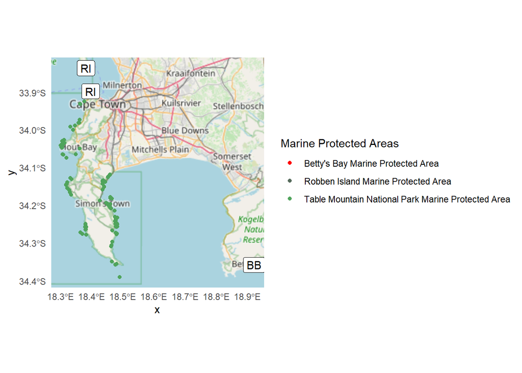

```r
# Find BB MPA localities
bb <- algae_data %>% filter(CUR_NME %in% c("Betty's Bay Marine Protected Area"))

# Find RI MPA localities
ri <- algae_data %>% filter(CUR_NME %in% c("Robben Island Marine Protected Area"))

# Label Betty's Bay (BB) MPA and Robben Island (RI) MPA
ggplot() +
  annotation_map_tile(type = "osm", progress = "none") +
  geom_sf(data = algae_data, aes(col = CUR_NME)) +
  scale_colour_manual(values = pal) +
  labs(color = "Marine Protected Areas") +  # Rename the legend title here
  geom_sf_label(data = bb %>% filter(CUR_NME == "Betty's Bay Marine Protected Area"), aes(label = "BB")) +
  geom_sf_label(data = ri %>% filter(CUR_NME == "Robben Island Marine Protected Area"), aes(label = "RI")) +
  theme_minimal()
```

Figure 12: Map of three seaweed species occurrences within existing South African Marine Protected Areas, records from Betty’s Bay and Robben Island MPAs are labelled.

The distribution analysis of the three agar-producing seaweed species indicates that many records fall outside established Marine Protected Areas. To support the agar industry, expanding the Robben Island MPA eastward and extending the Betty’s Bay MPA should be considered.

Data sources

SA Marine Protected Area Zonations Data - Department of Forestry, Fisheries and the Environment

Species Occurrence Data - [iNaturalist](https://www.inaturalist.org/)